# Analysis of CNV buffering at the protein level

### load R packages

```r
library(tidyverse)

# set nest and unnest functions to the previous tidyr version
# current versions (tidyr 1.0.0) are very slow
nest <- nest_legacy
unnest <- unnest_legacy
```

### load data

```r
# read table with multi-omics data (protein, mRNA and CNV)
multi_omics <- read_tsv("./multi_omics_data.txt.gz")
multi_omics
```

| gene | sample | prot_log2FC | rna_log2CPM | cnv_gistic2 |
| --- | --- | --- | --- | --- |
| A1BG | AU565 | NA | -0.3681702344 | 0 |
| A2M | AU565 | -0.088412597 | 0.7088567486 | 1 |
| A2ML1 | AU565 | 1.041659869 | 1.6177416193 | 1 |
| AAAS | AU565 | 1.151497932 | 1.7030193831 | 1 |
| AACS | AU565 | 1.770390807 | 1.5041293585 | -1 |
| AAGAB | AU565 | -0.659577922 | -1.0114211297 | -1 |
| AAK1 | AU565 | -0.051423347 | 0.2097078534 | 1 |
| AAMP | AU565 | -0.147988986 | 1.4559489470 | 1 |
| AARS | AU565 | -2.007432914 | -1.4434182291 | -1 |
| AARS2 | AU565 | 0.019597217 | 0.1728826656 | -1 |

[output cut: 990 more lines]

```r
## simplify column names
multi_omics <- multi_omics %>%
  rename(protein = prot_log2FC, rna = rna_log2CPM, cnv = cnv_gistic2)
multi_omics
```

| gene | sample | protein | rna | cnv |
| --- | --- | --- | --- | --- |
| A1BG | AU565 | NA | -0.3681702344 | 0 |
| A2M | AU565 | -0.088412597 | 0.7088567486 | 1 |
| A2ML1 | AU565 | 1.041659869 | 1.6177416193 | 1 |
| AAAS | AU565 | 1.151497932 | 1.7030193831 | 1 |
| AACS | AU565 | 1.770390807 | 1.5041293585 | -1 |
| AAGAB | AU565 | -0.659577922 | -1.0114211297 | -1 |
| AAK1 | AU565 | -0.051423347 | 0.2097078534 | 1 |
| AAMP | AU565 | -0.147988986 | 1.4559489470 | 1 |
| AARS | AU565 | -2.007432914 | -1.4434182291 | -1 |
| AARS2 | AU565 | 0.019597217 | 0.1728826656 | -1 |

[output cut: 990 more lines]

```r
# this is how you could do it with base R:
#colnames(multi_omics)[3] <- "protein"
#colnames(multi_omics)[4] <- "rna"
#colnames(multi_omics)[5] <- "cnv"
# not so cleaner...

# read table with metadata (cancer type, experimental study, etc.)
metadata <- read_tsv("./samples_metadata.txt")
metadata
```

| sample | cancer | batch | proteomics | gender | age |
| --- | --- | --- | --- | --- | --- |
| TCGA.A2.A0T2 | BRCA | TCGA_BRCA | TMT | FEMALE | 66 |
| TCGA.A2.A0CM | BRCA | TCGA_BRCA | TMT | FEMALE | 40 |
| TCGA.BH.A18V | BRCA | TCGA_BRCA | TMT | FEMALE | 48 |
| TCGA.BH.A18Q | BRCA | TCGA_BRCA | TMT | FEMALE | 56 |
| TCGA.BH.A0E0 | BRCA | TCGA_BRCA | TMT | FEMALE | 38 |
| TCGA.A7.A0CE | BRCA | TCGA_BRCA | TMT | FEMALE | 57 |
| TCGA.D8.A142 | BRCA | TCGA_BRCA | TMT | FEMALE | 74 |
| TCGA.A2.A0D0 | BRCA | TCGA_BRCA | TMT | FEMALE | 60 |
| TCGA.AO.A0J6 | BRCA | TCGA_BRCA | TMT | FEMALE | 61 |
| TCGA.A2.A0YM | BRCA | TCGA_BRCA | TMT | FEMALE | 67 |

[output cut: 455 more lines]

```r
# read table containing the samples with protein, mRNA and CNV data
samples <- read_tsv("./samples_prot_rna_cnv.txt", col_names = F)

## add cancer type
samples <- samples %>%
  rename(sample = X1) %>%
  inner_join(metadata[, c("sample", "cancer")], by = "sample")
```

### simple barplot with the number of samples by cancer type

geom_bar() counts the number of cases at each x position by default, making the height of the bar proportional to that number

therefore we do not provide an y variable (it is computed internally by ggplot2)

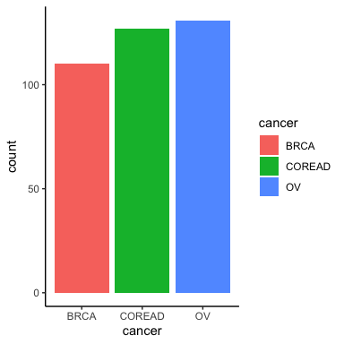

```r
samples_barplot <- ggplot(data = samples, mapping = aes(x = cancer, fill = cancer)) +
  geom_bar() +
  theme_classic()
samples_barplot
```

```r
# in case you want to save the plot to a pdf file uncomment the following line
#ggsave(filename = file.path(".", "samples_barplot.pdf"), plot = samples_barplot, height = 4, width = 4)
```

# CNV buffering analysis

### set up a simple correlation function

df must a data.frame or tibble

x and y the variables to select and correlate from df

uses pearson correlation by default

the output is a table with two columns, one with the correlation and other with the respective P-value

```r
corr <- function(df, x, y, method = "pearson"){
  a = df[[x]]
  b = df[[y]]
  cor <- broom::tidy(cor.test(a, b, method = method))

  stats = c("corr", "pval")
  cols = rep(list(c(x, y)), 2)
  nms <- map2_chr(.x = stats, .y = cols, .f = ~ str_c(c(.x, .y), collapse = "_"))

  res <- cor %>%
    select(estimate, p.value) %>%
    rename_all(.funs = ~ nms)

  return(res)
}
```

### calculate the correlations between the CNV and the RNA and the CNV and the protein

```r
# CNV and mRNA correlation for each gene across samples
# after nesting the data by gene, we call the corr() function for each gene
cnv_rna_corr <- multi_omics %>%
  group_by(gene) %>%
  nest() %>%
  ungroup() %>%
  mutate(correlations = map(.x = data, .f = corr, x = "cnv", y = "rna")) %>%
  select(-data) %>%
  unnest() %>%
  select(-pval_cnv_rna)
cnv_rna_corr
```

| gene | corr_cnv_rna |
| --- | --- |
| A1BG | 0.087093625 |
| A2M | 0.073458107 |
| A2ML1 | 0.187410969 |
| AAAS | 0.507312840 |
| AACS | 0.384729724 |
| AAGAB | 0.547435932 |
| AAK1 | 0.165284056 |
| AAMP | 0.469740311 |
| AARS | 0.381193366 |
| AARS2 | 0.516992994 |

[output cut: 990 more lines]

```r
# this is how you could do it with base R:
#cnv_rna_corr <- data.frame()
#for(g in unique(multi_omics$gene)){
#  temp_df <- multi_omics[multi_omics$gene == g, ]
#  corrs <- corr(temp_df, x = "cnv", y = "rna")
#  corrs <- cbind(g, corrs)
#  colnames(corrs)[1] <- "gene"
#  cnv_rna_corr <- rbind(cnv_rna_corr, corrs)
#}
# besides not looking so clean it is also much slower...


# CNV and protein correlation for each gene across samples
cnv_protein_corr <- multi_omics %>%
  group_by(gene) %>%
  nest() %>%
  ungroup() %>%
  mutate(correlations = map(.x = data, .f = corr, x = "cnv", y = "protein")) %>%
  select(-data) %>%
  unnest() %>%
  select(-pval_cnv_protein)
cnv_protein_corr
```

| gene | corr_cnv_protein |
| --- | --- |
| A1BG | -0.048183792 |
| A2M | 0.006470728 |
| A2ML1 | 0.187958779 |
| AAAS | 0.060926953 |
| AACS | 0.231256156 |
| AAGAB | 0.353839626 |
| AAK1 | 0.091891729 |
| AAMP | 0.367420407 |
| AARS | 0.338110054 |
| AARS2 | 0.359290834 |

[output cut: 990 more lines]

### merge both correlations

```r
cnv_rna_protein_corr <- inner_join(cnv_rna_corr, cnv_protein_corr, by = "gene")
cnv_rna_protein_corr
```

| gene | corr_cnv_rna | corr_cnv_protein |
| --- | --- | --- |
| A1BG | 0.087093625 | -0.048183792 |
| A2M | 0.073458107 | 0.006470728 |
| A2ML1 | 0.187410969 | 0.187958779 |
| AAAS | 0.507312840 | 0.060926953 |
| AACS | 0.384729724 | 0.231256156 |
| AAGAB | 0.547435932 | 0.353839626 |
| AAK1 | 0.165284056 | 0.091891729 |
| AAMP | 0.469740311 | 0.367420407 |
| AARS | 0.381193366 | 0.338110054 |
| AARS2 | 0.516992994 | 0.359290834 |

[output cut: 990 more lines]

### calculate the attenuation potential as the correlation differences: cor(CNV, RNA) - cor(CNV, Protein)

higher attenuation potentials may indicate genes whose CNVs are buffered at the protein level

```r
cnv_rna_protein_corr <- cnv_rna_protein_corr %>%
  mutate(attenuation = corr_cnv_rna - corr_cnv_protein) %>%
  arrange(desc(attenuation))
cnv_rna_protein_corr
```

| gene | corr_cnv_rna | corr_cnv_protein | attenuation |
| --- | --- | --- | --- |
| PDCD7 | 0.6185705 | -9.463459e-02 | 0.7132051 |
| SPOP | 0.6270380 | -7.477756e-02 | 0.7018155 |
| TOX4 | 0.6778397 | -1.343320e-02 | 0.6912729 |
| ARPC1A | 0.5571211 | -1.239239e-01 | 0.6810449 |
| COPS5 | 0.6569911 | -1.749925e-02 | 0.6744903 |
| SMARCB1 | 0.5714618 | -9.553567e-02 | 0.6669975 |
| KIAA1429 | 0.6271399 | -3.615936e-02 | 0.6632993 |
| UTP3 | 0.6270999 | -3.480247e-02 | 0.6619023 |
| SPCS1 | 0.4829532 | -1.696879e-01 | 0.6526411 |
| RCL1 | 0.6606394 | 9.365490e-03 | 0.6512739 |

[output cut: 990 more lines]

```r
NA
```

### example of the CNV attenuation at the protein level for the gene TOX4

component of the PTW/PP1 phosphatase complex (plays a role in the control of cell cycle progression, during the transition from mitosis into interphase)

```r
# let's filter the multi-omics data by selecting the TOX4 gene
attenuation_example <- multi_omics %>%
  filter(gene == "TOX4")
attenuation_example
```

| gene | sample | protein | rna | cnv |
| --- | --- | --- | --- | --- |
| TOX4 | AU565 | 0.488885757 | 1.811883324 | 2 |
| TOX4 | BT20 | -0.474217381 | 0.234142655 | 1 |
| TOX4 | BT474 | 1.043572167 | 1.625043460 | 2 |
| TOX4 | BT549 | -0.775528895 | -0.536871289 | -1 |
| TOX4 | C2BBE1 | -0.254013872 | 0.341135844 | -1 |
| TOX4 | CAMA1 | 0.497260097 | 0.299195449 | -1 |
| TOX4 | CCK81 | 0.787237808 | 0.011838674 | 0 |
| TOX4 | CL11 | 0.395588455 | 0.606858396 | 0 |
| TOX4 | CL40 | -0.737643023 | 0.692079553 | 0 |
| TOX4 | COLO678 | 0.376963417 | 0.732241140 | 0 |

[output cut: 358 more lines]

### we will plot the RNA and protein measures across the different CNV levels

-2 = homozygous deletion; -1 = hemizygous deletion; 0 = heterozygotic/no change; 1 = gain; 2 = high level amplification

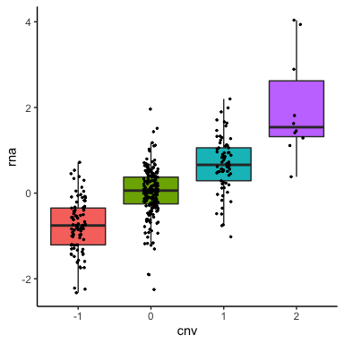

```r
# CNV vs RNA
cnv_rna_example <- attenuation_example %>%
  ggplot(mapping = aes(x = cnv, y = rna, group = cnv, fill = as.character(cnv))) +
  geom_boxplot(outlier.shape = NA) +
  geom_jitter(width = 0.1, size = 0.5) +
  scale_fill_discrete(guide = F) +
  theme_classic()
cnv_rna_example
```

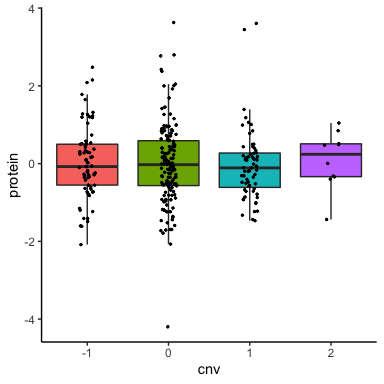

```r
# in case you want to save the plot to a pdf file uncomment the following line
#ggsave(filename = file.path(".", "cnv_rna_example.pdf"), plot = cnv_rna_example, height = 4, width = 4)


# CNV vs protein
cnv_protein_example <- attenuation_example %>%
  ggplot(mapping = aes(x = cnv, y = protein, group = cnv, fill = as.character(cnv))) +
  geom_boxplot(outlier.shape = NA) +
  geom_jitter(width = 0.1, size = 0.5) +
  scale_fill_discrete(guide = F) +
  theme_classic()
cnv_protein_example
```

```r
# in case you want to save the plot to a pdf file uncomment the following line
#ggsave(filename = file.path(".", "cnv_protein_example.pdf"), plot = cnv_protein_example, height = 4, width = 4)
```

### can you do now the same for a gene that is not attenuated?

let’s filter the data for positive attenuation values to exclude the genes that are more correlated with the protein than with the RNA

they are not many and we think they are the result of sequencing errors or splicing isoforms (we might not be measuring the correct isoform at the RNA level)

```r
cnv_rna_protein_corr %>%
  filter(attenuation > 0) %>%
  arrange(attenuation)
```

| gene | corr_cnv_rna | corr_cnv_protein | attenuation |
| --- | --- | --- | --- |
| PDCD5 | 0.4248390280 | 0.424570139 | 0.0002688892 |
| IRF3 | 0.4883888804 | 0.488115952 | 0.0002729286 |
| SCEL | 0.1782507713 | 0.177780250 | 0.0004705211 |
| PRTFDC1 | 0.2551950046 | 0.254693593 | 0.0005014118 |
| GNAQ | 0.3076239584 | 0.307078966 | 0.0005449923 |
| RBPMS | 0.2469266270 | 0.246341144 | 0.0005854829 |
| HCLS1 | 0.1160238840 | 0.115434080 | 0.0005898039 |
| ANXA1 | 0.2222260447 | 0.221554900 | 0.0006711442 |
| GGPS1 | 0.4448502932 | 0.443956082 | 0.0008942116 |
| ADAT1 | 0.4528502722 | 0.451948291 | 0.0009019808 |

[output cut: 990 more lines]

### try to reproduce the same plot as before for the PDCD5 gene (involved in cellular apoptosis)

start by filtering the multi-omics dataset

you can re-use the code

```r
# let's filter the multi-omics data by selecting the PDCD5 gene
attenuation_example2 <- multi_omics %>%
  filter(gene == "PDCD5")
attenuation_example2
```

| gene | sample | protein | rna | cnv |
| --- | --- | --- | --- | --- |
| PDCD5 | AU565 | 0.930541494 | -0.086570074 | 0 |
| PDCD5 | BT20 | -0.293557727 | -0.555560383 | 1 |
| PDCD5 | BT474 | -1.079774859 | -1.053190334 | 1 |
| PDCD5 | BT549 | 1.191939070 | 1.077300623 | -1 |
| PDCD5 | C2BBE1 | 0.320372937 | 0.492766541 | 0 |
| PDCD5 | CAMA1 | 0.366312119 | 0.295285937 | 0 |
| PDCD5 | CCK81 | 0.365410311 | 0.181446391 | 0 |
| PDCD5 | CL11 | -0.318345469 | 0.152475727 | 0 |
| PDCD5 | CL40 | -1.109205732 | -0.423041067 | 0 |
| PDCD5 | COLO678 | -0.512205502 | -1.760587901 | -1 |

[output cut: 358 more lines]

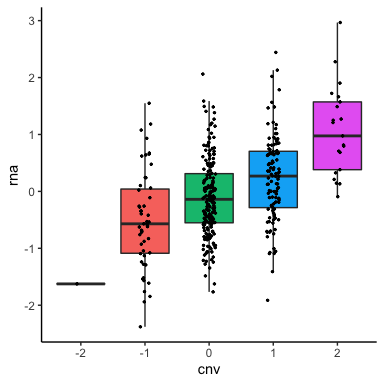

```r
# CNV vs RNA
cnv_rna_example2 <- attenuation_example2 %>%
  ggplot(mapping = aes(x = cnv, y = rna, group = cnv, fill = as.character(cnv))) +
  geom_boxplot(outlier.shape = NA) +
  geom_jitter(width = 0.1, size = 0.5) +
  scale_fill_discrete(guide = F) +
  theme_classic()
cnv_rna_example2
```

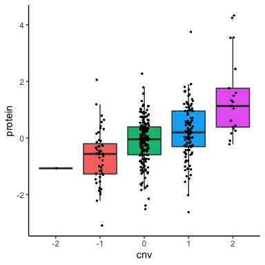

```r
# in case you want to save the plot to a pdf file uncomment the following line
#ggsave(filename = file.path(".", "cnv_rna_example2.pdf"), plot = cnv_rna_example2, height = 4, width = 4)


# CNV vs protein
cnv_protein_example2 <- attenuation_example2 %>%
  ggplot(mapping = aes(x = cnv, y = protein, group = cnv, fill = as.character(cnv))) +
  geom_boxplot(outlier.shape = NA) +
  geom_jitter(width = 0.1, size = 0.5) +
  scale_fill_discrete(guide = F) +
  theme_classic()
cnv_protein_example2
```

```r
# in case you want to save the plot to a pdf file uncomment the following line
#ggsave(filename = file.path(".", "cnv_protein_example2.pdf"), plot = cnv_protein_example2, height = 4, width = 4)
```

### make a scatterplot with the cor(CNV, RNA) in the x axis and the cor(CNV, Protein) in the y axis

the genes with the highest attenuation at the protein level will be in the bottom-right corner

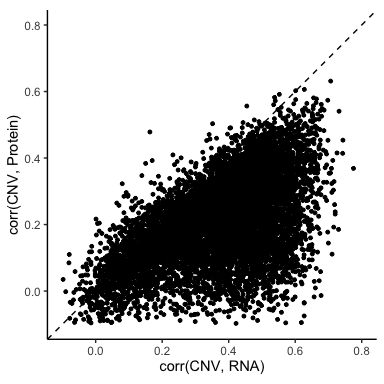

```r
attenuation_plot1 <- ggplot(data = cnv_rna_protein_corr, mapping = aes(x = corr_cnv_rna, y = corr_cnv_protein)) +
  geom_point(size=1) +
  geom_abline(slope=1, intercept=0, linetype=2, color="black") +
  theme_classic() +
  coord_fixed() +
  scale_x_continuous(limits = c(-0.1, 0.8)) +
  scale_y_continuous(limits = c(-0.1, 0.8)) +
  labs(x = "corr(CNV, RNA)", y = "corr(CNV, Protein)")
attenuation_plot1
```

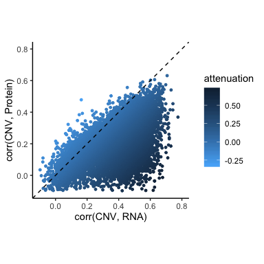

```r
# in case you want to save the plot to a pdf file uncomment the following line
#ggsave(filename = file.path(".", "attenuation_plot1.pdf"), plot = attenuation_plot1, height = 4, width = 4)

# color the points by attenuation potential
attenuation_plot2 <- ggplot(data = cnv_rna_protein_corr, mapping = aes(x = corr_cnv_rna, y = corr_cnv_protein, color = attenuation)) +
  geom_point(size=1) +
  geom_abline(slope=1, intercept=0, linetype=2, color="black") +
  theme_classic() +
  coord_fixed() +
  scale_color_gradient(low = "#56B1F7", high = "#132B43") +
  scale_x_continuous(limits = c(-0.1, 0.8)) +
  scale_y_continuous(limits = c(-0.1, 0.8)) +
  labs(x = "corr(CNV, RNA)", y = "corr(CNV, Protein)")
attenuation_plot2
```

```r
# in case you want to save the plot to a pdf file uncomment the following line
#ggsave(filename = file.path(".", "attenuation_plot2.pdf"), plot = attenuation_plot2, height = 4, width = 4)
```

### perform a GO enrichment analysis on the more attenuated genes (top 1000 genes)

we will use a GO over-representation test based on the hypergeometric distribution:

check this page for further details: https://yulab-smu.top/biomedical-knowledge-mining-book/enrichment-overview.html#ora-algorithm

```r
# select the top 1000 attenuated genes
attenuated_genes <- cnv_rna_protein_corr %>%
  top_n(n = 1000,  wt = attenuation)

# the attenuated genes are supposed to be enriched in protein complexes
# therefore we will select the Cellular Component (CC) ontology
enr_object <- clusterProfiler::enrichGO(gene = attenuated_genes$gene, universe = cnv_rna_protein_corr$gene, ont = "CC", OrgDb = org.Hs.eg.db::org.Hs.eg.db, keyType = "SYMBOL")
```

```r
# extract the enrichment table from the enrichResult object
# transform it to a tibble
# select the significantly enriched categories (p.adjust < 0.05)
enr_table <- enr_object@result %>%
  as_tibble() %>%
  filter(p.adjust < 0.05)
```

### make a barplot with the top 30 enriched categories

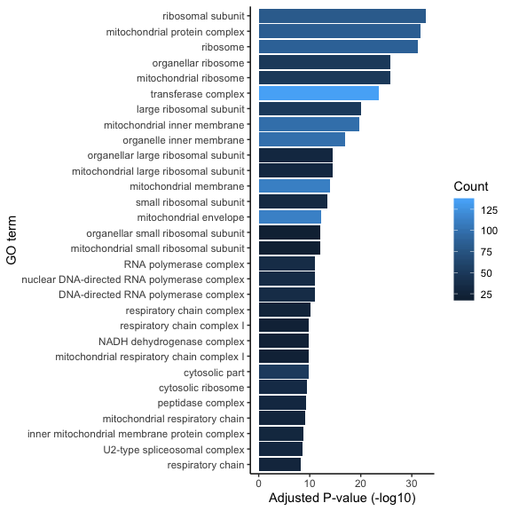

```r
# transform the adjusted P-values using the negative value of the logarithm base 10 (-log10):
# low values will have the highest values, and vice-versa
# reorder the categories using the -log10 adjusted P-values
categories <- enr_table %>%
  mutate(log10_p = -log10(p.adjust)) %>%
  top_n(n = 30, wt = log10_p) %>%
  mutate(Description = fct_reorder(.f=Description, .x=log10_p, .fun = function(x) x))

categories_barplot <- ggplot(data = categories, mapping = aes(x = Description, y = log10_p, fill = Count)) +
  geom_col() +
  coord_flip() +
  theme_classic() +
  labs(x = "GO term", y = "Adjusted P-value (-log10)")
categories_barplot
```

```r
# in case you want to save the plot to a pdf file uncomment the following line
#ggsave(filename = file.path(".", "categories_barplot.pdf"), plot = categories_barplot, height = 6, width = 6)
```

# Does the attenuation depend on the cancer type?

### To answer this question we will perform the CNV buffering analysis by cancer type

### To make it simpler, let’s just compare the breast and ovarian cancers

the protein abundances have missing values, which might make it impossible to calculate the CNV buffering of some genes in some tissues

to make sure we will calculate the CNV buffering for the same set of genes along the cancer types, we will select the genes that have at least 10 samples with protein measures in each cancer type

```r
# first set up a function that will calculate the number of samples per cancer type
# after that it evaluates whether or not the number of samples is at least 10 in the 2 tissues
# the output will be TRUE if the last statement is true, and FALSE otherwise
select_genes <- function(df){
  grouped <- df %>%
    group_by(cancer) %>%
    summarise(n = n()) %>%
    ungroup() %>%
    summarise(higher_10 = sum(n >= 10) == 2) %>%
    pull(higher_10)

  return(grouped)
}

# now we can select the genes
# first we remove the missing values from the protein abundance
# then we add the cancer type using the table with the metadata
# after nesting the data by gene, we call the select_genes() function we just created for each gene
multi_omics2 <- multi_omics %>%
  filter(!is.na(protein)) %>%
  inner_join(metadata[, c("sample", "cancer")], by = "sample") %>%
  filter(cancer != "COREAD") %>%
  group_by(gene) %>%
  nest() %>%
  ungroup() %>%
  mutate(genes_to_keep = map_lgl(.x = data, .f = select_genes)) %>%
  filter(genes_to_keep) %>%
  select(-genes_to_keep) %>%
  unnest()
multi_omics2
```

| gene | sample | protein | rna | cnv | cancer |
| --- | --- | --- | --- | --- | --- |
| A2M | AU565 | -0.088412597 | 0.7088567486 | 1 | BRCA |
| A2M | BT20 | -0.011090304 | -0.8551362406 | 1 | BRCA |
| A2M | BT549 | 0.798267803 | -0.8029305860 | -1 | BRCA |
| A2M | CAMA1 | -0.906678164 | -0.5440793268 | -1 | BRCA |
| A2M | DU4475 | 0.739274384 | 0.3864356554 | 0 | BRCA |
| A2M | HCC1187 | 0.726309520 | -0.6848934061 | 1 | BRCA |
| A2M | HCC1395 | 1.653095567 | 1.3713389953 | 2 | BRCA |
| A2M | HCC1419 | -1.511397131 | -0.7415985667 | 0 | BRCA |
| A2M | HCC1428 | -0.367288591 | -0.4679765951 | 0 | BRCA |
| A2M | HCC1569 | 2.773563140 | 2.9712771110 | 0 | BRCA |

[output cut: 990 more lines]

```r
# faster way of doing the same with less code (and no need for an external function)
# multi_omics2 <- multi_omics %>%
#   filter(!is.na(protein)) %>%
#   inner_join(metadata[, c("sample", "cancer")], by = "sample") %>%
#   filter(cancer != "COREAD") %>%
#   group_by(gene) %>%
#   filter(sum(table(cancer) >= 10) == 2) %>%
#   ungroup()
```

### calculate again the correlations between the CNV and the RNA and the CNV and the protein

```r
# CNV and mRNA correlation for each gene across samples for each cancer type
cnv_rna_corr2 <- multi_omics2 %>%
  group_by(cancer, gene) %>%
  nest() %>%
  ungroup() %>%
  mutate(correlations = map(.x = data, .f = corr, x = "cnv", y = "rna")) %>%
  select(-data) %>%
  unnest() %>%
  select(-pval_cnv_rna)
cnv_rna_corr2
```

| cancer | gene | corr_cnv_rna |
| --- | --- | --- |
| BRCA | A2M | 0.105445707 |
| OV | A2M | 0.061560797 |
| BRCA | A2ML1 | 0.188081051 |
| OV | A2ML1 | 0.283915279 |
| BRCA | AAAS | 0.588633034 |
| OV | AAAS | 0.515402890 |
| BRCA | AACS | 0.309154648 |
| OV | AACS | 0.425269306 |
| BRCA | AAGAB | 0.592589938 |
| OV | AAGAB | 0.565299329 |

[output cut: 990 more lines]

```r
# CNV and protein correlation for each gene across samples for each cancer type
cnv_protein_corr2 <- multi_omics2 %>%
  group_by(cancer, gene) %>%
  nest() %>%
  ungroup() %>%
  mutate(correlations = map(.x = data, .f = corr, x = "cnv", y = "protein")) %>%
  select(-data) %>%
  unnest() %>%
  select(-pval_cnv_protein)
cnv_protein_corr2
```

| cancer | gene | corr_cnv_protein |
| --- | --- | --- |
| BRCA | A2M | -0.0122883595 |
| OV | A2M | 0.0118947972 |
| BRCA | A2ML1 | 0.2168110812 |
| OV | A2ML1 | 0.1610642890 |
| BRCA | AAAS | 0.0646042977 |
| OV | AAAS | 0.1597605441 |
| BRCA | AACS | 0.1937215217 |
| OV | AACS | 0.3127135829 |
| BRCA | AAGAB | 0.3834412748 |
| OV | AAGAB | 0.4443719488 |

[output cut: 990 more lines]

### merge both correlations

```r
cnv_rna_protein_corr2 <- inner_join(cnv_rna_corr2, cnv_protein_corr2, by = c("cancer", "gene"))
cnv_rna_protein_corr2
```

| cancer | gene | corr_cnv_rna | corr_cnv_protein |
| --- | --- | --- | --- |
| BRCA | A2M | 0.105445707 | -0.0122883595 |
| OV | A2M | 0.061560797 | 0.0118947972 |
| BRCA | A2ML1 | 0.188081051 | 0.2168110812 |
| OV | A2ML1 | 0.283915279 | 0.1610642890 |
| BRCA | AAAS | 0.588633034 | 0.0646042977 |
| OV | AAAS | 0.515402890 | 0.1597605441 |
| BRCA | AACS | 0.309154648 | 0.1937215217 |
| OV | AACS | 0.425269306 | 0.3127135829 |
| BRCA | AAGAB | 0.592589938 | 0.3834412748 |
| OV | AAGAB | 0.565299329 | 0.4443719488 |

[output cut: 990 more lines]

### calculate attenuation potential as before

```r
cnv_rna_protein_corr2 <- cnv_rna_protein_corr2 %>%
  mutate(attenuation = corr_cnv_rna - corr_cnv_protein) %>%
  arrange(desc(attenuation))
cnv_rna_protein_corr2
```

| cancer | gene | corr_cnv_rna | corr_cnv_protein | attenuation |
| --- | --- | --- | --- | --- |
| OV | RRN3 | 0.8850940 | -0.4087834074 | 1.2938774 |
| OV | USP33 | 0.7863803 | -0.3305167457 | 1.1168971 |
| OV | SLC26A6 | 0.6952776 | -0.3907544932 | 1.0860321 |
| OV | PRMT7 | 0.7823856 | -0.2231790780 | 1.0055646 |
| OV | RBM18 | 0.9142179 | -0.0650343095 | 0.9792522 |
| OV | MAD2L1BP | 0.7696568 | -0.2011468424 | 0.9708036 |
| BRCA | UTP15 | 0.6909014 | -0.2342525567 | 0.9251540 |
| OV | L3MBTL2 | 0.5751753 | -0.3409277086 | 0.9161030 |
| OV | FAR1 | 0.7671192 | -0.1438528448 | 0.9109720 |
| OV | B4GALT3 | 0.8109799 | -0.0954564493 | 0.9064363 |

[output cut: 990 more lines]

### as before, make a scatterplot with the cor(CNV, RNA) in the x axis and the cor(CNV, Protein) in the y axis

however, this time we will do one plot for each cancer type using the ggplot2 function facet_wrap()

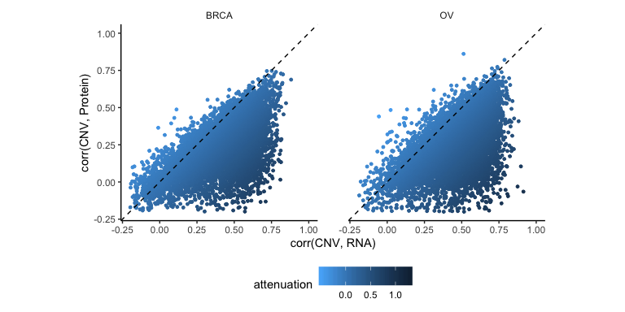

```r
attenuation_plot3 <- ggplot(data = cnv_rna_protein_corr2, mapping = aes(x = corr_cnv_rna, y = corr_cnv_protein, color = attenuation)) +
  geom_point(size=1) +
  geom_abline(slope=1, intercept=0, linetype=2, color="black") +
  theme_classic() +
  theme(
    panel.spacing = unit(1, "cm"),
    strip.background = element_blank(),
    legend.position = "bottom") +
  coord_fixed() +
  facet_wrap(facets = vars(cancer), nrow = 1) +
  scale_color_gradient(low = "#56B1F7", high = "#132B43") +
  scale_x_continuous(limits = c(-0.2, 1)) +
  scale_y_continuous(limits = c(-0.2, 1)) +
  labs(x = "corr(CNV, RNA)", y = "corr(CNV, Protein)")
attenuation_plot3
```

```r
# in case you want to save the plot to a pdf file uncomment the following line
#ggsave(filename = file.path(".", "attenuation_plot3.pdf"), plot = attenuation_plot3, height = 4, width = 8)
```

# compare the gene attenuation scores between the two cancer types

### first let’s make a new table with the attenuation scores in two separate columns

```r
attenuation_scores <- cnv_rna_protein_corr2 %>%
  arrange(gene) %>%
  select(gene, cancer, attenuation) %>%
  pivot_wider(names_from = "cancer", values_from = "attenuation")
attenuation_scores
```

[output not shown]

[output cut: 990 more lines]

### finally, we can compare the attenuation scores by doing a scatterplot

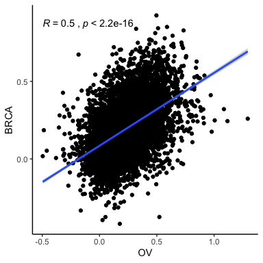

```r
# add also a Pearson correlation coefficient using the function stat_cor() from the ggpubr package
library(ggpubr)
brca_ov_attenuation <- ggplot(data = attenuation_scores, mapping = aes(x = OV, y = BRCA)) +
  geom_point() +
  geom_smooth(method = "lm") +
  stat_cor() +
  theme_classic()
brca_ov_attenuation
```

```r
# in case you want to save the plot to a pdf file uncomment the following line
#ggsave(filename = file.path(".", "brca_ov_attenuation.pdf"), plot = brca_ov_attenuation, height = 4, width = 4)
```